# Kanban

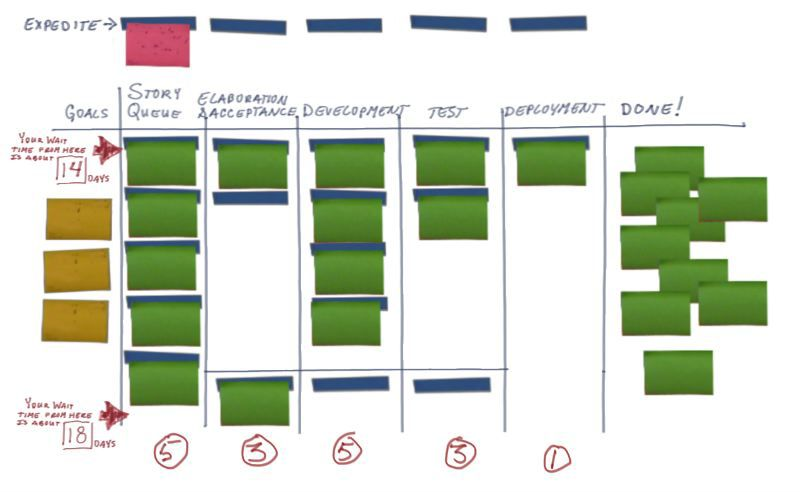

Кирилл Корняков (Intel), Антон Бевзюк (DODO Pizza)  
Ноябрь 2018

# Содержание

- Истоки
- Scrum and Kanban
- Разбор на примере
- Заключение

# Философия

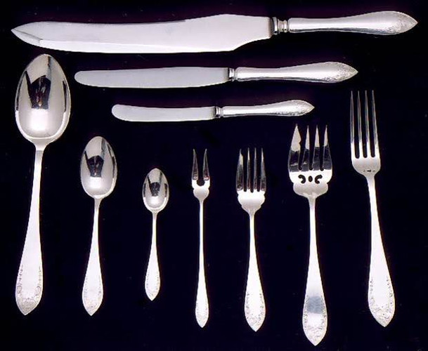

[figure not shown]

# Объем методологии

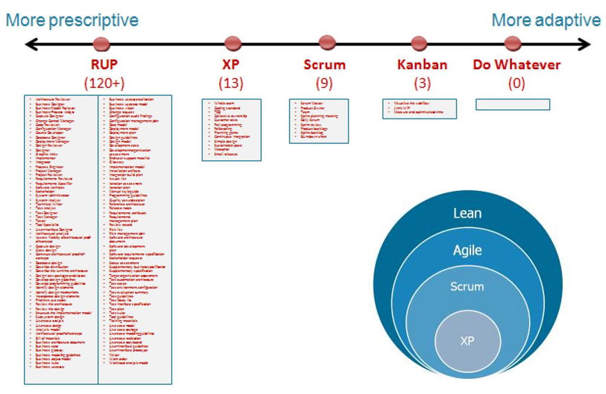

# Toyota Production System

Цель — избавление процесса от:

1. Перегрузки / стресса (muri)
2. Несогласованности (mura)
3. Напрасных потерь (muda)

# Toyota Production System

1. **Continuous Improvement**
2. **Respect** for People
3. Long-term philosophy
4. The right process will produce the right results
5. Add value to the organization by **developing your people and partners**
6. **Continuously solving root problems** drives organizational learning

# Kanban

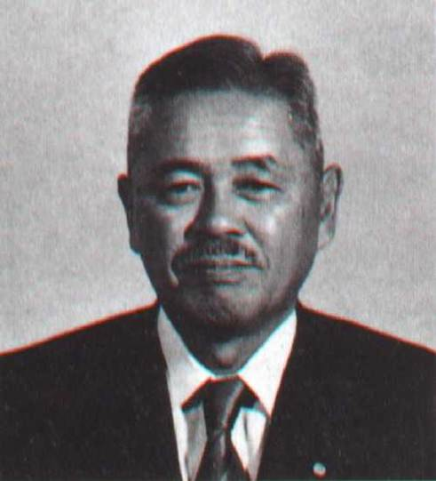

[figure not shown]

# Распространение

- Toyota Production System
  - 1948 - 1975
- Lean Manufacturing
  - 1990s
- Lean Software Development
  - 2000s

# Содержание

- Истоки
- **Scrum and Kanban**
- Разбор на примере
- Заключение

# Scrum в двух слайдах (1)

- Большая группа долго создаёт большую штуку
- Маленькая группа быстро создаёт маленькую
- И постоянно интегрируется

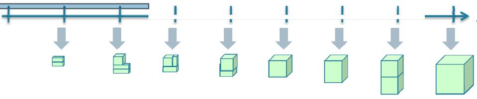

# Scrum в двух слайдах (2)

- Backlog
- Iterations
- Team

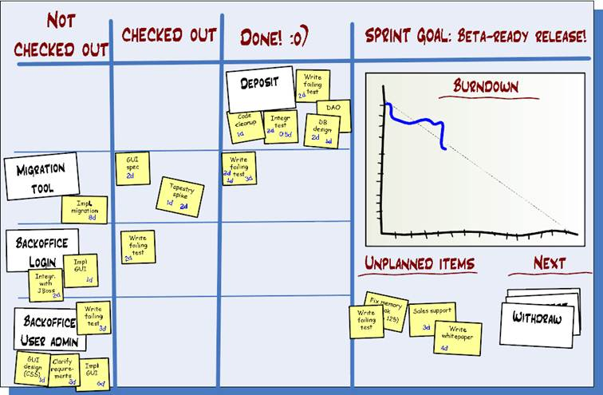

# Канбан в трех слайдах (1)

**Практики Канбан**

1. Visualize (the work, workflow and business risks)
2. Limit WIP
3. Manage Flow
4. Make Process Explicit
5. Implement Feedback Loops
6. Improve Collaboratively, Evolve Experimentally (using models & the scientific method)

# Канбан в трех слайдах (2)

**Принципы внедрения Канбан**

1. Start with what you do now
2. Agree to pursue incremental evolutionary change
3. Respect the current process, roles, responsibilities and titles
4. Leadership at all levels

# Канбан в трех слайдах (3)

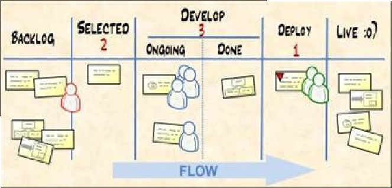

**Lead Time —> min**

# Длина итерации

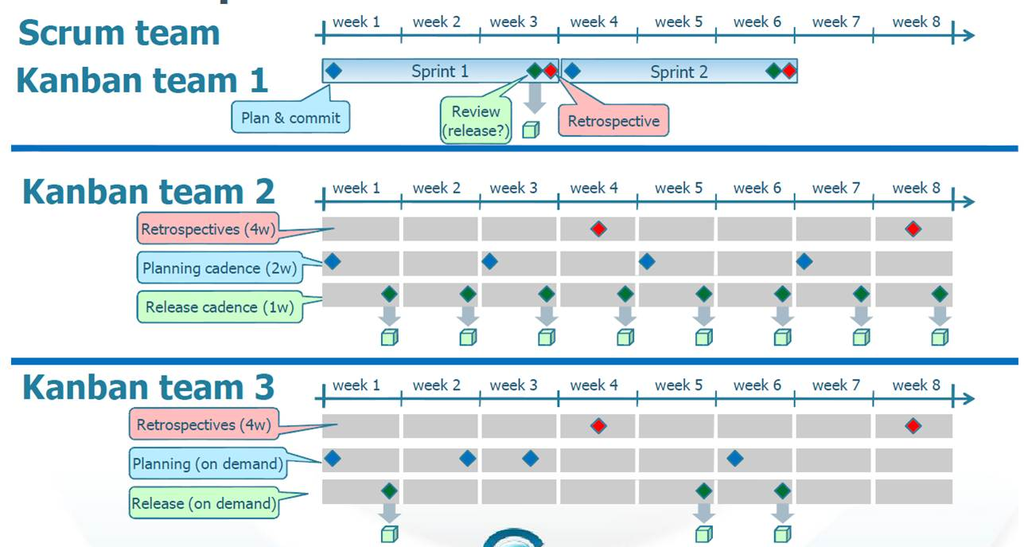

# Ограничение WIP

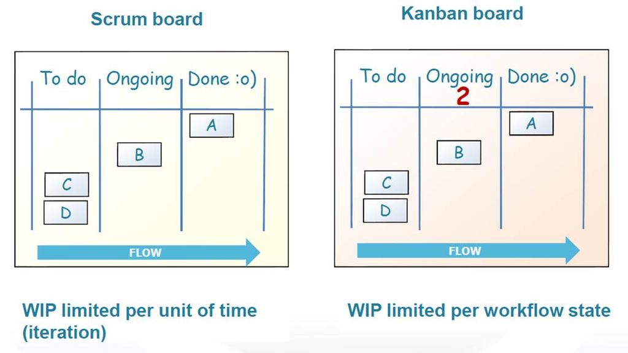

# Ограничение WIP

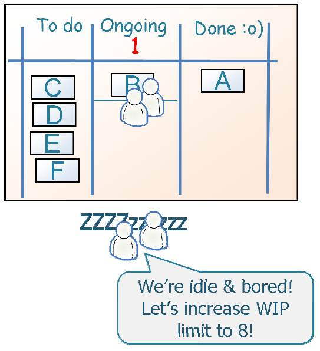

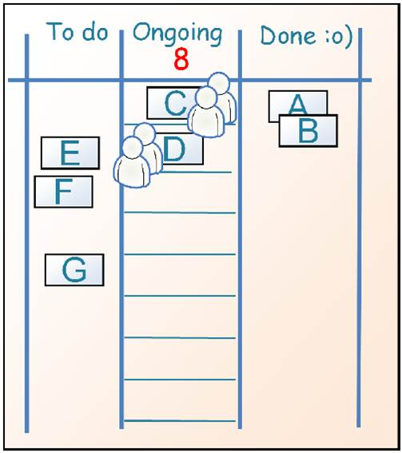

# Ограничение WIP

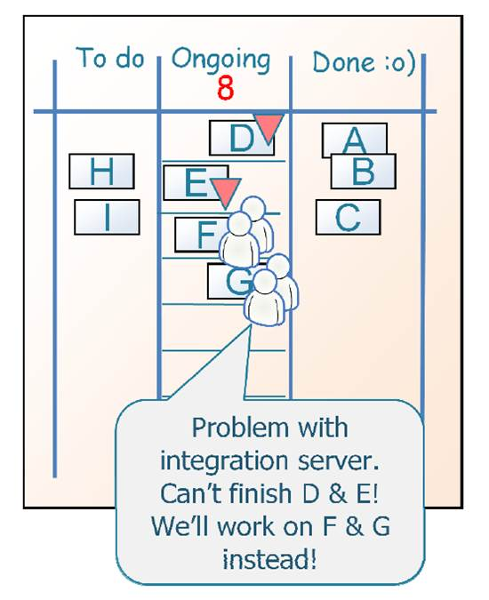

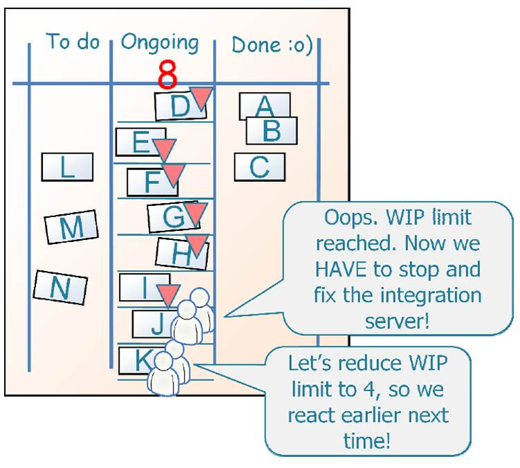

# Доска

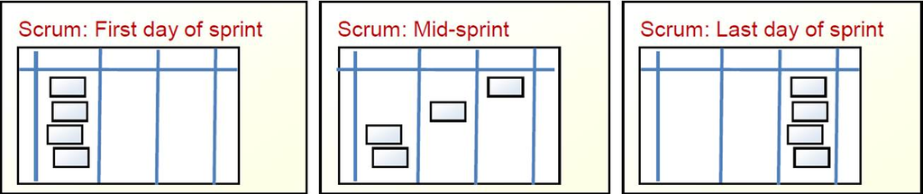

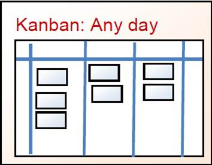

# Длительные задачи

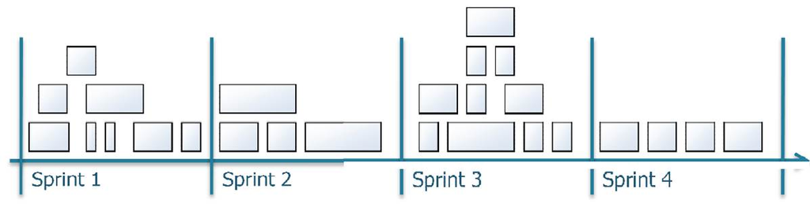

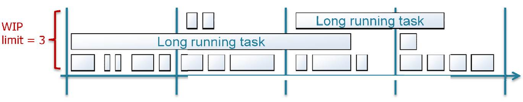

# Оценки / скорость

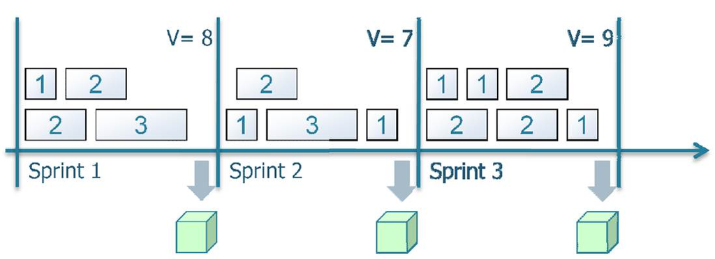

# Дырокол и кондуктор

[figure not shown]

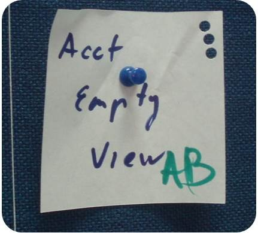

# Наша доска

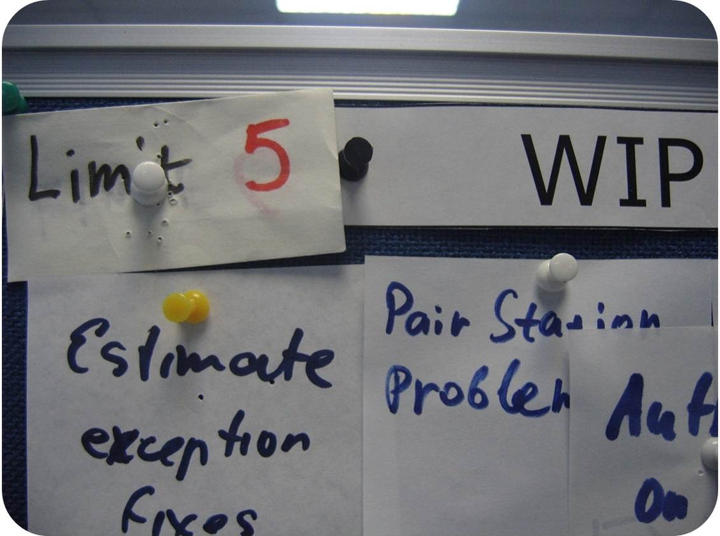

# Оба - Lean & Agile

- Pull rather than push
- Kaizen
- Реагировать на изменения важнее, чем следовать плану

# Сходства

- Lean & Agile
- Pull rather than push
- Ограничение WIP
- Улучшение процесса
- Ранние и частые релизы
- Самоорганизующиеся команды
- Разбиение работы на части
- Планирование на основании эмпирических данных

# Отличия

| **SCRUM** |  | **KANBAN** |
| --- | --- | --- |
| Итерации ограничены во времени |  | Итерации не ограничены |
| **Команда обязуется сделать** |  | **Обязательства не обязательны** |
| Velocity — метрика для планирования |  | Lead Time — метрика для планирования |
| и улучшения процесса |  | и улучшения процесса |
| **Многофункциональная команда** |  | **Многофункциональная команда не обязательна** |
| Истории должны помещаться в спринт |  | Нет ограниений на размер истории |
| **Burndown chart** |  | **Не обязательно** |
| Неявное ограничение WIP (на спринт) |  | Явное ограничение WIP |
| **Оценки** |  | **Не обязательно** |
| Backlog фиксирован на спринт |  | Можно добавлять истории в любой момент |
| **Backlog для одной команды** |  | **Backlog может использоваться несколькими командами** |
| 3 роли |  | Ролей нет |
| **Доска очищается в конце спринта** |  | **Доска постоянная** |
| Приоритезированный backlog |  | Не обязательно |

# Содержание

- Истоки
- Scrum and Kanban
- **Разбор на примере**
- Заключение

# Один день из жизни Канбан

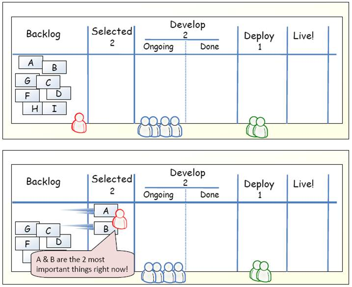

# Один день из жизни Канбан

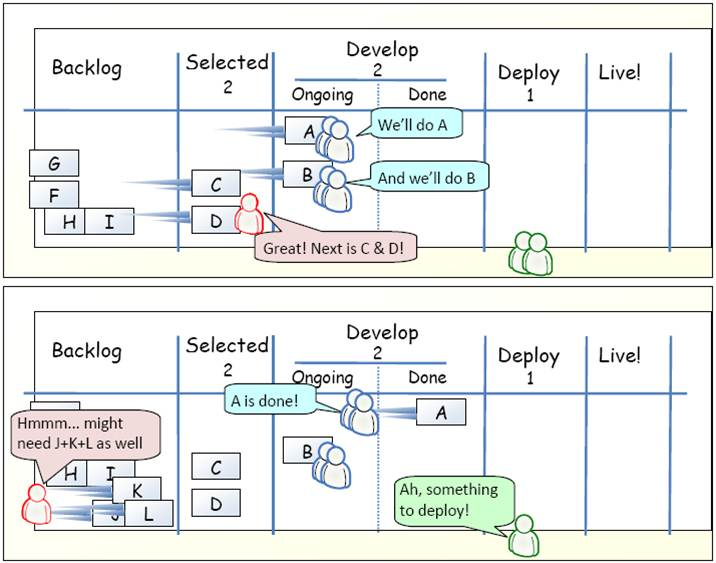

# Один день из жизни Канбан

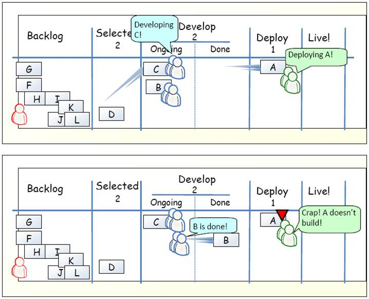

# Один день из жизни Канбан

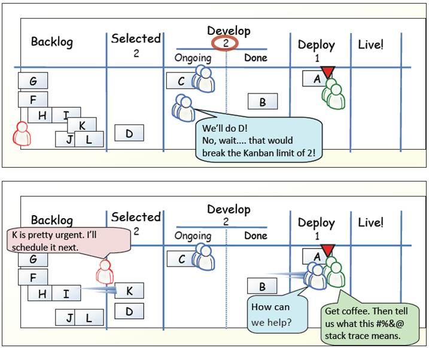

# Один день из жизни Канбан

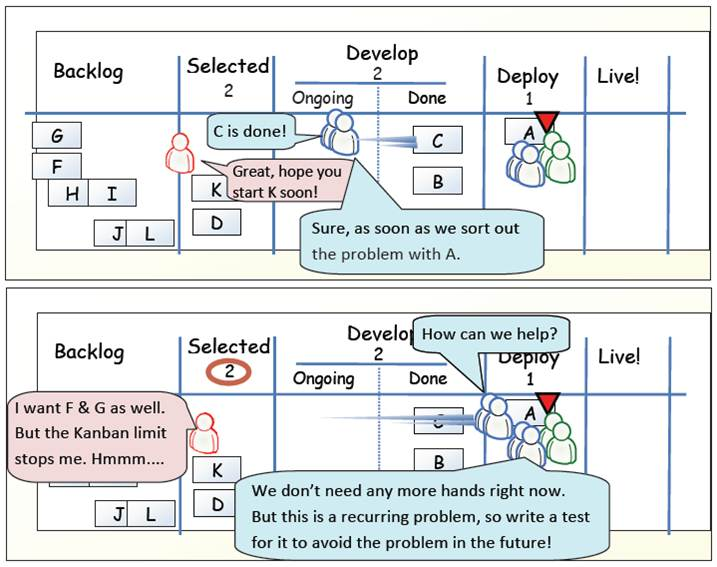

# Один день из жизни Канбан

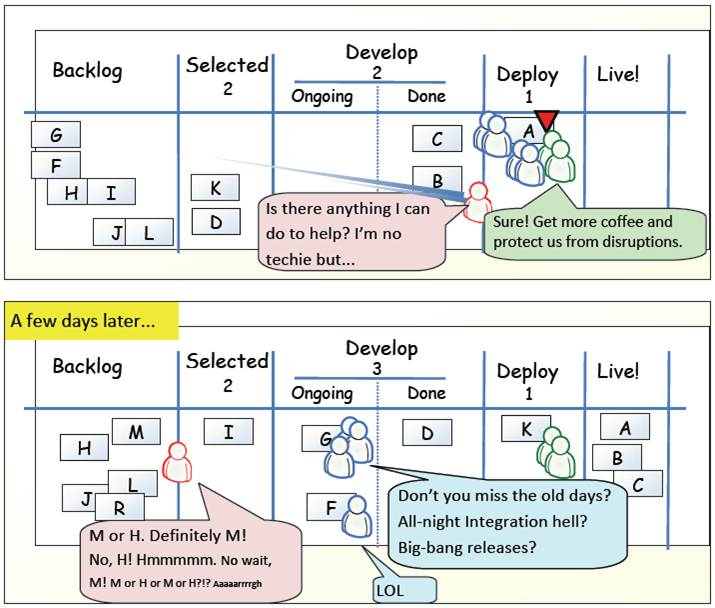

# Содержание

- Истоки
- Scrum and Kanban
- Разбор на примере
- **Заключение**

# Инструменты не решают

- Успешный проект — хороший инструмент
- Успешный проект — плохой инструмент
- Провальный проект — плохой инструмент
- Провальный проект — хороший инструмент

# Выбор инструмента

> "Не привязывайся к одному оружию или стилю"

Миямото Мусаси, самурай, 17 век

[figure not shown]

# Заключение

1. Понимайте свои цели
2. Не вините инструменты
3. Не ограничивайте себя одним инструментом
4. Эксперементируйте и наслаждайтесь поездкой

# Контрольные вопросы

1. Цели TPS
2. Принципы TPS
3. Практики Канбан
4. Принципы внедрения Канбан
5. В чем смысл ограничения WIP? Приведите примеры того, где это помогает оптимизировать процесс.
6. Назовите сходства Scrum и Kanban
7. Назовите отличия Scrum и Kanban

# Дополнительные источники

- [Скрам и Канбан: выжимаем максимум](http://scrum.org.ua/wp-content/uploads/ScrumAndKanbanRuFinal.pdf)

# Спасибо за внимание!

Вопросы?